# Clean LENA 5-minute data

Lucy King & Fran Querdasi

## Environment set up

```r
# Libraries
library(tidyverse)
library(lubridate)
library(hms)
library(psych)
# Files
lena_5min_file_1 <- "~/Desktop/BABIES/lena_symptoms/data_final/LENAExport_5Minute_20181220_cleaned.csv"
lena_5min_file_2 <- "~/Desktop/BABIES/lena_symptoms/data_final/LENAExport_5Minute_new_20190726.csv"
lena_5min_files <- "~/Desktop/BABIES/lena_symptoms/data_final/individual_5min_lsk_format_cleaned"
lena_followup_long_file <- "~/Desktop/BABIES/lena_symptoms/data_final/lena_followup_long_datecleaned_20190726.csv"
lena_followup_cs_file <- "~/Desktop/BABIES/lena_symptoms/data_final/lena_followup_cs_datecleaned_20190216.csv"
lena_5min_files_df <-
  tibble(
    path =
      list.files(
        path = lena_5min_files,
        all.files = TRUE,
        #pattern = "^LENA Export (5 Minute) \\d{3}_\\d{6}.csv$",
        no.. = TRUE,
        full.names = TRUE
      )
  ) %>%
  filter(
    str_detect(path, "/.DS_Store") == FALSE
  )
# Functions
source("~/Desktop/BABIES/lena_symptoms/lena_18mo_symptoms/identify_outliers_histogram.R")
source("~/Desktop/BABIES/lena_symptoms/lena_18mo_symptoms/winsorize.R")
# Themes
theme_lena <-
  theme_minimal() +
  theme(
    panel.grid = element_blank(),
    plot.title = element_text(size = 18, hjust = .5),
    axis.title = element_text(size = 18),
    axis.text = element_text(size = 16),
    legend.title = element_text(size = 18),
    legend.text = element_text(size = 16),
    legend.position = "bottom"
  )
```

# Read in and reformat 5 minute data from LENA SP

```r
lena_5min_sp <-
  read_csv(lena_5min_file_2) %>%
  mutate(
    ExternalReferenceID = as.integer(ExternalReferenceID),
    Recording_DOB = as.character(Recording_DOB),
    StartTime = as.character(StartTime)
  ) %>%
  select(
    ExternalReferenceID,
    Recording_DOB,
    StartTime,
    Duration_Secs,
    AWC_COUNT,
    CT_COUNT,
    CV_COUNT,
    Recording_Gender,
    Meaningful,
    Distant,
    TV_Elec,
    Overlap,
    Noise,
    Silence
  ) %>%
  mutate(
    ID = ExternalReferenceID,
    dob = Recording_DOB,
    AWC.Actual = AWC_COUNT,
    CTC.Actual = CT_COUNT,
    CVC.Actual = CV_COUNT,
    Sex = Recording_Gender,
    Duration = as.hms(Duration_Secs),
    Meaningful = as.hms(Meaningful),
    Distant = as.hms(Distant),
    TV = as.hms(TV_Elec),
    Overlap = as.hms(Overlap),
    Noise = as.hms(Noise),
    Silence = as.hms(Silence),
    Timestamp = StartTime
  ) %>%
  select(
    -ExternalReferenceID,
    -Recording_DOB,
    -Recording_Gender,
    -CT_COUNT,
    -CV_COUNT,
    -AWC_COUNT,
    -Duration_Secs
  ) %>%
  mutate(
    Timestamp = str_replace(Timestamp, " \\(America/Los_Angeles\\)", ""),
    time_record = parse_date_time(Timestamp, "mdy HMS p!")
  ) %>%
  select(
    -Timestamp
  )
```

## Read in 5-minute LENA Pro data and combine with LENA SP data

```r
lena_5min <-
  read_csv(lena_5min_file_1) %>%
  mutate(
    Birthdate = as.character(Birthdate),
    Timestamp = as.character(Timestamp),
    Meaningful = as.hms(Meaningful)
  ) %>%
  select(
    -Type,
    -ChildKey,
    -Id,
    -Age,
    -AVA_StdScore:-AVA_AvgScore_Pct,
    -Firstname,
    ID = Lastname,
    dob = Birthdate
  ) %>%
  mutate(
    time_record = parse_date_time(Timestamp, "mdy HM")
  ) %>%
  bind_rows(
    lena_5min_sp
  ) %>%
  mutate(
    ID = as.numeric(ID)
  ) %>%
  select(
    -Timestamp
  )
```

## Read in data from individual files (Pro license 1)

```r
lena_5min2 <-
  lena_5min_files_df %>%
  mutate(
    data = map(
      path,
      read_csv,
      col_names = TRUE,
      col_types =
        list(
          Firstname = col_character(),
          Birthdate = col_character(),
          Timestamp = col_character(),
          AVA_StdScore = col_character(),
          Lastname = col_character(),
          Sex = col_character(),
          ChildKey = col_character()
        )
      )
  ) %>%
  unnest(data) %>%
  select(-path) %>%
  mutate(
    Birthdate = as.character(Birthdate),
    Timestamp = as.character(Timestamp)
  ) %>%
  select(
    -Type,
    -ChildKey,
    -Id,
    -Age,
    -AVA_StdScore:-AVA_AvgScore_Pct,
    ID1 = Firstname,
    ID2 = Lastname,
    dob = Birthdate
  ) %>%
  mutate(
    ID = as.numeric(
      if_else(
        is.na(ID2),
        ID1, ID2
      )
    ),
    time_record = parse_date_time(Timestamp, c("mdy HM", "ymd HM"))
  ) %>%
  select(
    ID,
    everything(),
    -Timestamp,
    -ID1,
    -ID2
  )
```

## Combine all data

```r
lena_5min <-
  lena_5min %>%
  bind_rows(lena_5min2) %>%
  arrange(ID) %>%
  mutate(
    dob = parse_date_time(dob, c("Ymd", "mdy")),
    date_record = date(time_record),
    age = (dob %--% date_record) / months(1)
  )
```

## Create long-form data frame with time variables

```r
lena_time <-
  lena_5min %>%
  group_by(ID) %>%
  mutate(
    time_hours = hour(time_record) + minute(time_record) / 60,
    duration = as.numeric(
      as.duration(hms(as.numeric(Duration))),
      "hours"
    )
  )
```

# Clean and wrangle 5-minute data

Conditions to filter on: age between 5 and 8 months at time of recording, duration of recording at least 8 hours.

```r
lena_5min_cl <-
  lena_5min %>%
  group_by(ID) %>%
  mutate(
    duration = as.numeric(
      as.duration(hms(as.numeric(Duration))),
      "hours"
    )
  ) %>%
  group_by(ID, date_record, age) %>%
  summarise(
    duration = sum(duration),
    awc_depend_sum = sum(AWC.Actual >= 1),
    ctc_depend_sum = sum(CTC.Actual >= 1),
    cvc_depend_sum = sum(CVC.Actual >= 1),
    awc_total = sum(AWC.Actual),
    ctc_total = sum(CTC.Actual),
    cvc_total = sum(CVC.Actual),
    awc_max = max(AWC.Actual),
    ctc_max = max(CTC.Actual),
    cvc_max = max(CVC.Actual)
  ) %>%
  mutate(
    awc_daily_rate_dur = awc_total/duration, #daily AWC rate
    ctc_daily_rate_dur = ctc_total/duration, #daily CTC rate
    cvc_daily_rate_dur = cvc_total/duration, #daily CVC rate
    awc_prop_dur = (awc_depend_sum) / ((duration * 60) / 5), #proportion of 5 minute segments with AWC
    ctc_prop_dur = (ctc_depend_sum) / ((duration * 60) / 5), #proportion of 5 minute segments with CTC
    cvc_prop_dur = (cvc_depend_sum) / ((duration * 60) / 5)
  ) %>%
  ungroup()
```

```r
lena_5min_cl <-
  lena_5min_cl %>%
  group_by(ID) %>%
  mutate(
    day_type = wday(date_record),
    day_type = if_else(day_type == 1 | day_type == 7, "weekend", "weekday"),
    day = 1:n()
  ) %>%
  ungroup()
```

```r
# identify who will be dropped
## based on age
lena_5min_cl %>%
  filter(day == 1) %>%
  count(age > 8)
```

| age > 8 | n |
| --- | --- |
| FALSE | 93 |
| TRUE | 11 |

```r
lena_5min_cl %>%
  filter(day == 1 & age > 8)
```

| ID | date_record | age | duration | awc_depend_sum | ctc_depend_sum | cvc_depend_sum | awc_total | ctc_total | cvc_total | awc_max | ctc_max | cvc_max | awc_daily_rate_dur | ctc_daily_rate_dur | cvc_daily_rate_dur | awc_prop_dur | ctc_prop_dur | cvc_prop_dur | day_type | day |
| --- | --- | --- | --- | --- | --- | --- | --- | --- | --- | --- | --- | --- | --- | --- | --- | --- | --- | --- | --- | --- |
| 24 | 2017-01-10 | 8.741935 | 29.92278 | 172 | 132 | 176 | 24618 | 594 | 1778 | 700 | 13 | 37 | 822.7177 | 19.85110 | 59.41962 | 0.4790108 | 0.3676129 | 0.4901506 | weekday | 1 |
| 25 | 2017-06-05 | 12.612903 | 16.00000 | 96 | 91 | 102 | 20113 | 610 | 2109 | 964 | 26 | 61 | 1257.0625 | 38.12500 | 131.81250 | 0.5000000 | 0.4739583 | 0.5312500 | weekday | 1 |
| 41 | 2017-01-14 | 8.580645 | 16.00000 | 118 | 79 | 112 | 12718 | 259 | 1043 | 441 | 14 | 47 | 794.8750 | 16.18750 | 65.18750 | 0.6145833 | 0.4114583 | 0.5833333 | weekend | 1 |
| 101 | 2018-03-23 | 8.129032 | 16.00000 | 133 | 86 | 117 | 20528 | 272 | 691 | 748 | 12 | 37 | 1283.0000 | 17.00000 | 43.18750 | 0.6927083 | 0.4479167 | 0.6093750 | weekday | 1 |
| 106 | 2018-03-19 | 8.258065 | 16.00000 | 100 | 83 | 104 | 21974 | 388 | 846 | 691 | 17 | 34 | 1373.3750 | 24.25000 | 52.87500 | 0.5208333 | 0.4322917 | 0.5416667 | weekday | 1 |
| 111 | 2018-03-20 | 8.419355 | 10.61000 | 98 | 70 | 88 | 12591 | 291 | 792 | 676 | 19 | 30 | 1186.7107 | 27.42696 | 74.64656 | 0.7697141 | 0.5497958 | 0.6911719 | weekday | 1 |
| 123 | 2018-09-03 | 10.419355 | 14.59306 | 103 | 81 | 104 | 10726 | 270 | 1002 | 453 | 15 | 39 | 735.0071 | 18.50195 | 68.66280 | 0.5881793 | 0.4625488 | 0.5938898 | weekday | 1 |
| 137 | 2018-09-29 | 8.700000 | 16.00000 | 118 | 91 | 110 | 18402 | 430 | 1393 | 511 | 28 | 51 | 1150.1250 | 26.87500 | 87.06250 | 0.6145833 | 0.4739583 | 0.5729167 | weekend | 1 |
| 1010 | 2018-02-08 | 10.107143 | 11.00000 | 106 | 72 | 97 | 15618 | 264 | 1152 | 506 | 18 | 111 | 1419.8182 | 24.00000 | 104.72727 | 0.8030303 | 0.5454545 | 0.7348485 | weekday | 1 |
| 1021 | 2018-06-25 | 8.233333 | 14.50000 | 116 | 83 | 101 | 18832 | 294 | 882 | 707 | 11 | 33 | 1298.7586 | 20.27586 | 60.82759 | 0.6666667 | 0.4770115 | 0.5804598 | weekday | 1 |

[output cut: 1 more lines]

```r
## based on duration
lena_5min_cl %>%
  filter(day == 1) %>%
  count(duration < 8)
```

| duration < 8 | n |
| --- | --- |
| FALSE | 103 |
| TRUE | 1 |

```r
lena_5min_cl %>%
  filter(day == 1 & duration < 8)
```

| ID | date_record | age | duration | awc_depend_sum | ctc_depend_sum | cvc_depend_sum | awc_total | ctc_total | cvc_total | awc_max | ctc_max | cvc_max | awc_daily_rate_dur | ctc_daily_rate_dur | cvc_daily_rate_dur | awc_prop_dur | ctc_prop_dur | cvc_prop_dur | day_type | day |
| --- | --- | --- | --- | --- | --- | --- | --- | --- | --- | --- | --- | --- | --- | --- | --- | --- | --- | --- | --- | --- |
| 12 | 2016-07-13 | 5.566667 | 1.309167 | 14 | 7 | 14 | 1050 | 16 | 161 | 257 | 5 | 62 | 802.0369 | 12.22151 | 122.979 | 0.8911521 | 0.4455761 | 0.8911521 | weekday | 1 |

```r
# ID 012 did not end up being dropped because day 2 was usable
```

```r
lena_5min_cl <-
  lena_5min_cl %>%
  filter(
    (age >= 5 & age <= 8),
    duration >= 8
  )
```

# Create wideform data frame with 1 row per ID

```r
lena_5min_day1_rename <-
  lena_5min_cl %>%
  filter(day == 1) %>%
  rename_at(
    vars(date_record:day_type),
    list(~paste0(., "_D1"))
  ) %>%
  select(-day)
lena_5min_day2_rename <-
  lena_5min_cl %>%
  filter(day == 2) %>%
  rename_at(
    vars(date_record:day_type),
    list(~paste0(., "_D2"))
  ) %>%
  select(-day)
lena_5min_cl_wf <-
  lena_5min_day1_rename %>%
  left_join(lena_5min_day2_rename, by = "ID") %>%
  distinct(ID, date_record_D1, ctc_daily_rate_dur_D1, .keep_all = TRUE) %>%
  group_by(ID) %>%
  mutate(
    ctc_max_D1D2 = max(ctc_max_D1, ctc_max_D2, na.rm = TRUE)
  ) %>%
  ungroup()
```

## Identifying problematic recordings:

__Deleted from raw data:__ 1052 5/8/18 recording, 62 Day 1 on 7/11/17 (from LENAExport_5minute_20181220). **Filter from analyses:** 56 Day 1, 110 Day 2, use 106 day 1 (day 2 not typical), use 1052 day 2 (day 1 “went to zoo for 90 min” but doesn’t say when), use 1045 day 2 (day 1 not whole day), 1010 use day 2 (mother worked 5 hrs day 1)

**Delete data with crowds:** -cleaned from raw data (files renamed “_cleaned“). Recordings with crowds:

cross-sectional: 27 9/18/16 15-16:00 (5 min files) 119 4/19/18 11:30-12:30 (20181220) 135 9/13/18 13-13:30 (20181220) 38 2/10/17 16-18 (20181220) 48 3/5/17 11-13 (20181220) 61 7/18/17 13-15 (20181220) 62 7/30/17 9:30-10:30 (2018), 76 8/21/17 15-16 (2018) 2 day 1 19:30-10 (5 min files) 28 day 1 13-15 (5 min files) 64 8/8/17 11-11:30 (2018) 75 9/15/17 12-15 (2018) 87 9/11/17 14:40-16:40 (2018) 105 3/15/18 16:45-16:55 (2018) 27 10/2/16 11-13 (5 min files) 19 5/12/18 13:30-17:30 (2018) 135 9/23/18 9-10:45 (2018) 12 day 2 12:20-13:50 (5 min files) 45 4/22/17 10:30-11:30 (2018) 50 3/18/17 9:45-12:45 (not completed correctly; entirely deleted) 60 7/16/17 14:30-16:30 (2018) 72 8/6/17 13-16 (2018) 94 4/15/18 12:30-14 (2018) 106 4/1/18 14:40-18:40 (2018) 115 4/14/18 13-14:30 (2018)

longitudinal: 1029 4/6/18 18:40-20:40 (2018) 1021 6/25/18 18-19:30 (2018) 1078 6/15/18 17:30-19:30 (2018) 1028 4/17/18 15:30-16 (2018) 1036 3/22/18 13:15-15:15 (2018) 1045 4/22/18 10-12 (2018) 1010 2/8/18 9:15-14:15 1028 5/6/18 15-19 (2018) 1036 5/5/18 8-9 16-17 (2018) 1045 5/19/18 10:30-12:30 (2018) 1011 5/13/18 15-16 (2018) 1019 5/20/18 16-17 (2018) 1023 5/12/18 11-13 (2018) 1060 9/29/18 17:30-18:30 (2018)

# Count weekdays vs weekends

```r
lena_5min_cl_wf %>%
  count(day_type_D1)
```

| day_type_D1 | n |
| --- | --- |
| weekday | 59 |
| weekend | 31 |

# Read in LENA follow up data

```r
lena_followup <-
  read_csv(lena_followup_long_file) %>%
  rename(ID = record_id) %>%
  mutate(ID = as.integer(ID)) %>%
  select(
    ID,
    lena_caregivers___1:percent_mother,
    lena_notes,
    lena_day_1_followup_questions_complete
  ) %>%
  filter(lena_day_1_followup_questions_complete == 2) %>%
  bind_rows(
    read_csv(lena_followup_cs_file) %>%
      rename(ID = record_id) %>%
      mutate(
        ID = as.integer(ID),
        lena_day_1_followup_questions_complete = as.integer(lena_day_1_followup_questions_complete)
      ) %>%
      select(
        ID,
        lena_caregivers___1:percent_mother,
        lena_notes,
        lena_day_1_followup_questions_complete
      ) %>%
      filter(lena_day_1_followup_questions_complete == 2)
  )
```

```
NAs introduced by coercion
```

```r
#IDs to use day 2:
# 110 (put device in pocket rather than chest day 1)
lena_5min_cl <-
  lena_5min_cl %>%
  mutate(
    day = if_else(
      ID == 110 & day == 1,
      NA_integer_, day
    ),
    day = if_else(
      ID == 110 & day == 2,
      as.integer(1), day
    )
  )
```

## Merge relevant follow up qs data with cleaned & filtered lena data

```r
lena_5min_cl <-
  lena_5min_cl %>%
  mutate(
    day_weekend_num = if_else(
      day_type == "weekend",
      1, 0
    )
  ) %>%
  rename(
    baby_age_lena = age
  )

lena_followup_and_data <-
  lena_5min_cl %>%
  mutate(
    date_record = parse_date_time(date_record, c("ymd", "mdy"))
  ) %>%
  left_join(
    lena_followup,
    by = c("ID")
  )
```

## Filter to only day 1 data

```r
lena_d1 <-
  lena_followup_and_data %>%
  filter(day == 1)
```

## Clean LENA time data

```r
ids_dates <-
  lena_d1 %>%
  select(
    ID,
    date_record
  ) %>%
  mutate(
    included = 1,
    date_record = date(date_record)
  )
lena_time_cl <-
  lena_time %>%
  left_join(ids_dates, by = c("ID", "date_record")) %>%
  filter(included == 1)
```

## Identify value and times of first and last CT and AW of the day

```r
lena_time_cl <-
  lena_time_cl %>%
  arrange(ID, time_hours) %>%
  group_by(ID) %>%
  mutate(
    # first ct
    ct_first_row = head(which(CTC.Actual != 0), 1),
    ct_first = nth(CTC.Actual, n = ct_first_row[1]),
    ct_first_time = nth(time_hours, n = ct_first_row[1]),
    # last ct
    ct_last_row = tail(which(CTC.Actual != 0), 1),
    ct_last = nth(CTC.Actual, n = ct_last_row[1]),
    ct_last_time = nth(time_hours, n = ct_last_row[1]),
    # first aw
    aw_first_row = head(which(AWC.Actual != 0), 1),
    aw_first = nth(AWC.Actual, n = aw_first_row[1]),
    aw_first_time = nth(time_hours, n = aw_first_row[1]),
    # last aw
    aw_last_row = tail(which(AWC.Actual != 0), 1),
    aw_last = nth(AWC.Actual, n = aw_last_row[1]),
    aw_last_time = nth(time_hours, n = aw_last_row[1]),
    # create grouping variable for time of day
    time_day = case_when(
      time_hours >= ct_first_time & time_hours <= 10 ~ "AM",
      time_hours >= 10 & time_hours < 13 ~ "MID",
      time_hours >= 13 & time_hours < 17 ~ "AFT",
      time_hours >= 17 & time_hours < ct_last_time ~ "PM"
    )
  ) %>%
  select(-ct_last_row, -aw_last_row, -ct_first_row, -aw_first_row)
```

[output not shown]

[output cut: 339 more lines]

## Merge time data

```r
lena_d1 <-
  lena_d1 %>%
  distinct(ID, ctc_daily_rate_dur, .keep_all = TRUE) %>%
  left_join(lena_time_wf, by = "ID")
```

# Summarize proportion variables

```r
lena_5min_cl_wf %>%
  summarise_at(
    vars(awc_prop_dur_D1, ctc_prop_dur_D1),
    funs(min, max, mean, sd), na.rm = TRUE
  )
```

| awc_prop_dur_D1_min | ctc_prop_dur_D1_min | awc_prop_dur_D1_max | ctc_prop_dur_D1_max | awc_prop_dur_D1_mean | ctc_prop_dur_D1_mean | awc_prop_dur_D1_sd | ctc_prop_dur_D1_sd |
| --- | --- | --- | --- | --- | --- | --- | --- |
| 0.3566925 | 0.1749227 | 0.8458577 | 0.7322963 | 0.621473 | 0.4520498 | 0.1000043 | 0.1010932 |

## Histograms

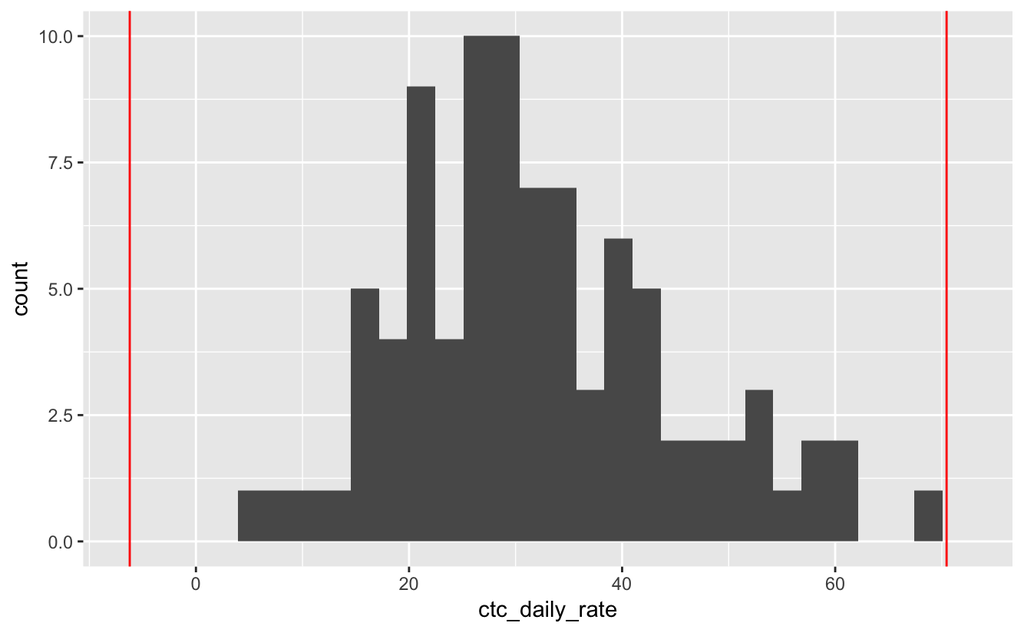

```r
identify_outliers_hist(lena_d1, ctc_daily_rate)
```

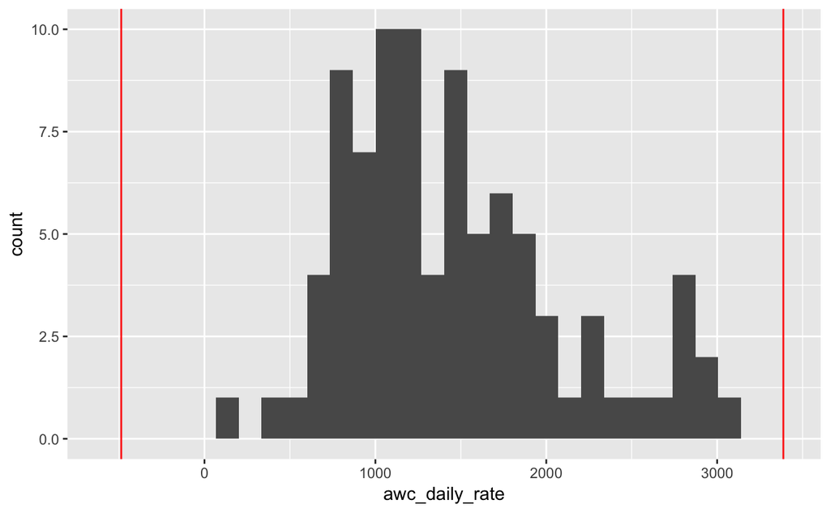

```r
identify_outliers_hist(lena_d1, awc_daily_rate)
```

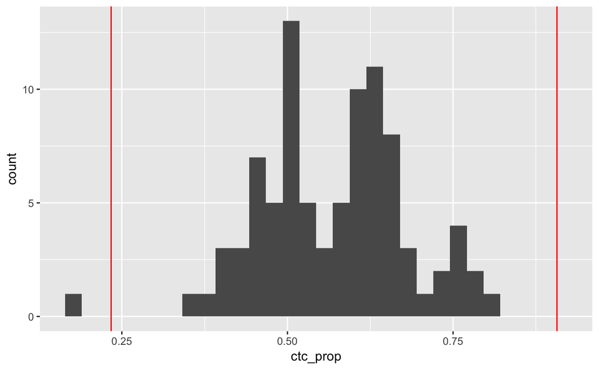

```r
identify_outliers_hist(lena_d1, ctc_prop)
```

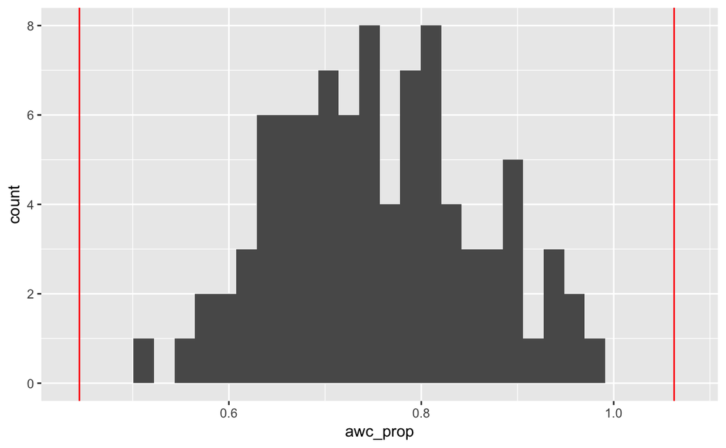

```r
identify_outliers_hist(lena_d1, awc_prop)
```

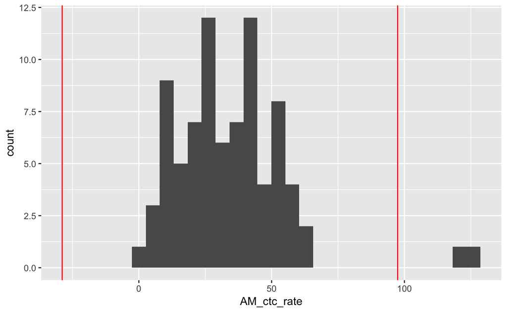

```r
identify_outliers_hist(lena_d1, AM_ctc_rate)
```

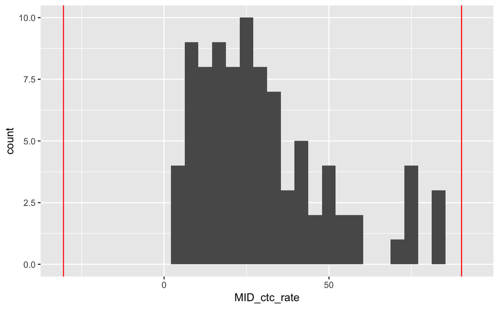

```r
identify_outliers_hist(lena_d1, MID_ctc_rate)
```

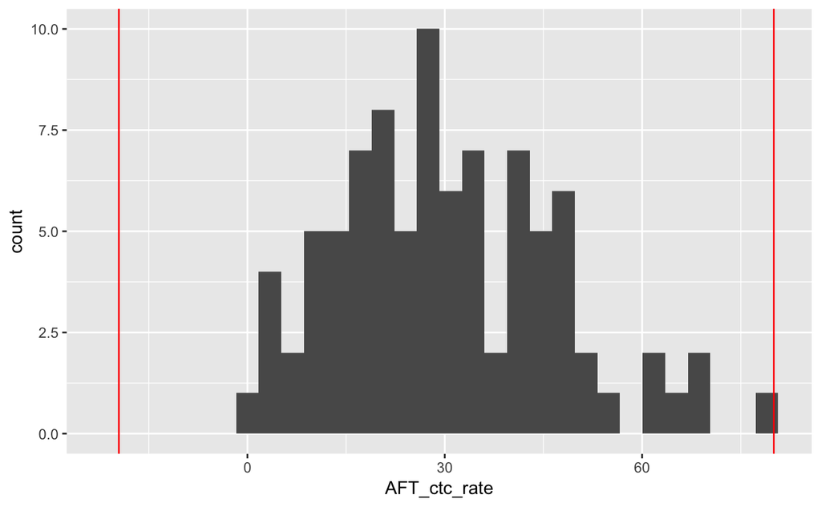

```r
identify_outliers_hist(lena_d1, AFT_ctc_rate)
```

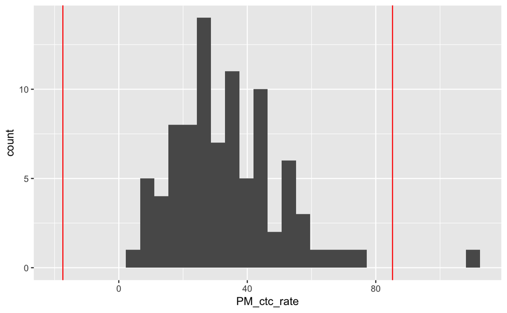

```r
identify_outliers_hist(lena_d1, PM_ctc_rate)
```

```r
# join first and last variables with day 1 LENA data
lena_d1 <-
  lena_d1 %>%
  left_join(
    lena_time_cl %>%
      select(
        ID,
        ct_last,
        ct_last_time,
        aw_last,
        aw_last_time,
        ct_first,
        ct_first_time,
        aw_first,
        aw_first_time
        ) %>%
      distinct(ID, ct_last, .keep_all = TRUE),
    by = "ID"
  )
```

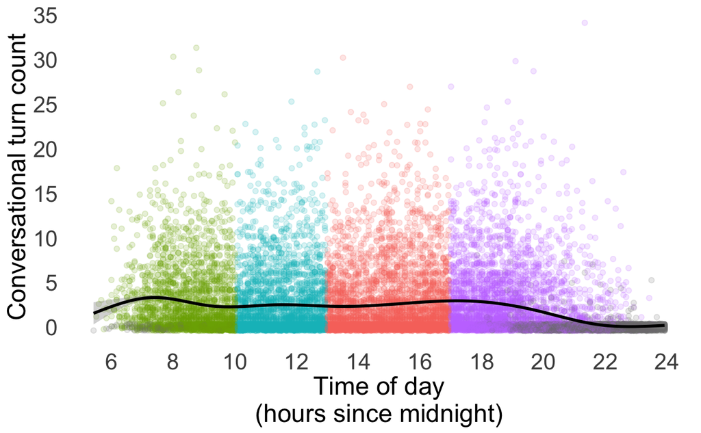

```r
lena_time_cl %>%
  ggplot(aes(time_hours, CTC.Actual)) +
  geom_jitter(alpha = 1/6, aes(color = time_day)) +
  geom_smooth(color = "black") +
  scale_x_continuous(breaks = seq.int(0, 24, 2)) +
  scale_y_continuous(breaks = seq.int(0, 35, 5)) +
  theme_lena +
  theme(
    legend.position = "none"
  ) +
  labs(
    x = "Time of day\n(hours since midnight)",
    y = "Conversational turn count"
  )
ggsave("~/Desktop/BABIES/lena_symptoms/manuscript/ctc_time_d1.png")
```

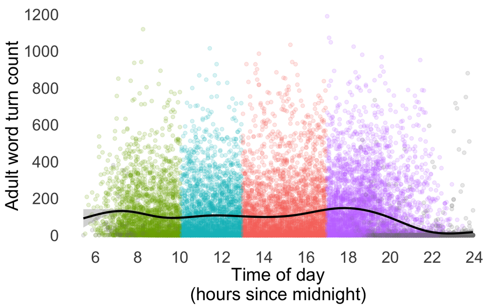

```r
lena_time_cl %>%
  ggplot(aes(time_hours, AWC.Actual)) +
  geom_jitter(alpha = 1/6, aes(color = time_day)) +
  geom_smooth(color = "black") +
  scale_x_continuous(breaks = seq.int(0, 24, 2)) +
  scale_y_continuous(breaks = seq.int(0, 1500, 200)) +
  theme_lena +
  theme(
    legend.position = "none"
  ) +
  labs(
    x = "Time of day\n(hours since midnight)",
    y = "Adult word turn count"
  )
ggsave("~/Desktop/BABIES/lena_symptoms/manuscript/awc_time_d1.png")
```

```r
missing_lena_ages <-
  lena_5min %>%
  left_join(ids_dates, by = c("ID", "date_record")) %>%
  filter(is.na(included)) %>%
  distinct(ID, age)
```

## Write file

```r
write_csv(lena_d1, "~/Desktop/BABIES/lena_symptoms/data_final/lena_d1_20191015.csv")
write_csv(lena_time_cl, "~/Desktop/BABIES/lena_symptoms/data_final/lena_d1_time_20191015.csv")
```